# Project 2

Logan Suchniak and Garrett Halford

5/4/2020

```r
library(readxl)
housing <- read_excel("Housing.xlsx")
#View(housing)
head(housing)
```

```
## # A tibble: 6 x 11
##      id price  size   lot  bath bedrooms yearbuilt agestandardized garagesize
##   <dbl> <dbl> <dbl> <dbl> <dbl>    <dbl>     <dbl>           <dbl>      <dbl>
## 1     1  388   2.18     4     3        4      1940            -3            0
## 2     2  450   2.05     5     3        4      1957            -1.3          2
## 3     3  386   2.11     5     2        4      1955            -1.5          2
## 4     4  350   1.44     6     1        2      1956            -1.4          1
## 5     5  156.  1.8      1     2        4      1994             2.4          1
## 6     6  220   1.96     5     2        3      1940            -3            1
## # … with 2 more variables: status <chr>, elem <chr>
```

```r
attach(housing)
```

## a.

First Candidate Model

```r
housing1 <- subset(housing, lot<8)
housing2 <- housing1[c(-4), ]
pow<-1/2
pricet<-(housing2$price)^pow
lg2<-lm(pricet~sqrt(lot)+bedrooms+garagesize+elem,data = housing2)
summary(lg2)
```

```
##
## Call:
## lm(formula = pricet ~ sqrt(lot) + bedrooms + garagesize + elem,
##     data = housing2)
##
## Residuals:
##      Min       1Q   Median       3Q      Max
## -2.60371 -0.88796  0.06165  0.67923  2.81833
##
## Coefficients:
##             Estimate Std. Error t value Pr(>|t|)
## (Intercept)  12.9646     1.5426   8.404 6.26e-12 ***
## sqrt(lot)     0.2205     0.4483   0.492 0.624474
## bedrooms     -0.1494     0.2451  -0.610 0.544293
## garagesize    0.8526     0.2321   3.673 0.000492 ***
## elemcrest     2.8936     1.0945   2.644 0.010300 *
## elemedge      1.8137     0.9799   1.851 0.068804 .
## elemedison    4.0713     1.0098   4.032 0.000150 ***
## elemharris    3.4528     1.0017   3.447 0.001007 **
## elemparker    1.8249     1.0095   1.808 0.075359 .
## ---
## Signif. codes:  0 '***' 0.001 '**' 0.01 '*' 0.05 '.' 0.1 ' ' 1
##
## Residual standard error: 1.306 on 64 degrees of freedom
## Multiple R-squared:  0.4974, Adjusted R-squared:  0.4345
## F-statistic: 7.916 on 8 and 64 DF,  p-value: 2.433e-07
```

This was the final model in project 1 therefore it is the first model.

```r
housing3<-housing[-1]
```

## b.

Second Candidate Model

```r
library(leaps)
regfit1<-regsubsets(price~.,data=housing3,nvmax=14,method="forward")
```

```
## Reordering variables and trying again:
```

```r
summary(regfit1)
```

```
## Subset selection object
## Call: regsubsets.formula(price ~ ., data = housing3, nvmax = 14, method = "forward")
## 14 Variables  (and intercept)
##                 Forced in Forced out
## size                FALSE      FALSE
## lot                 FALSE      FALSE
## bath                FALSE      FALSE
## bedrooms            FALSE      FALSE
## yearbuilt           FALSE      FALSE
## garagesize          FALSE      FALSE
## statuspen           FALSE      FALSE
## statussld           FALSE      FALSE
## elemcrest           FALSE      FALSE
## elemedge            FALSE      FALSE
## elemedison          FALSE      FALSE
## elemharris          FALSE      FALSE
## elemparker          FALSE      FALSE
## agestandardized     FALSE      FALSE
## 1 subsets of each size up to 13
## Selection Algorithm: forward
##           size lot bath bedrooms yearbuilt agestandardized garagesize statuspen
## 1  ( 1 )  " "  " " " "  " "      " "       " "             "*"        " "
## 2  ( 1 )  " "  " " " "  " "      " "       " "             "*"        " "
## 3  ( 1 )  " "  " " " "  " "      " "       " "             "*"        " "
## 4  ( 1 )  " "  "*" " "  " "      " "       " "             "*"        " "
## 5  ( 1 )  " "  "*" " "  " "      " "       " "             "*"        " "
## 6  ( 1 )  "*"  "*" " "  " "      " "       " "             "*"        " "
## 7  ( 1 )  "*"  "*" " "  "*"      " "       " "             "*"        " "
## 8  ( 1 )  "*"  "*" " "  "*"      " "       " "             "*"        " "
## 9  ( 1 )  "*"  "*" " "  "*"      " "       " "             "*"        "*"
## 10  ( 1 ) "*"  "*" "*"  "*"      " "       " "             "*"        "*"
## 11  ( 1 ) "*"  "*" "*"  "*"      "*"       " "             "*"        "*"
## 12  ( 1 ) "*"  "*" "*"  "*"      "*"       " "             "*"        "*"
## 13  ( 1 ) "*"  "*" "*"  "*"      "*"       " "             "*"        "*"
##           statussld elemcrest elemedge elemedison elemharris elemparker
## 1  ( 1 )  " "       " "       " "      " "        " "        " "
## 2  ( 1 )  " "       " "       " "      "*"        " "        " "
## 3  ( 1 )  " "       " "       " "      "*"        "*"        " "
## 4  ( 1 )  " "       " "       " "      "*"        "*"        " "
## 5  ( 1 )  "*"       " "       " "      "*"        "*"        " "
## 6  ( 1 )  "*"       " "       " "      "*"        "*"        " "
## 7  ( 1 )  "*"       " "       " "      "*"        "*"        " "
## 8  ( 1 )  "*"       " "       " "      "*"        "*"        "*"
## 9  ( 1 )  "*"       " "       " "      "*"        "*"        "*"
## 10  ( 1 ) "*"       " "       " "      "*"        "*"        "*"
## 11  ( 1 ) "*"       " "       " "      "*"        "*"        "*"
## 12  ( 1 ) "*"       " "       "*"      "*"        "*"        "*"
## 13  ( 1 ) "*"       "*"       "*"      "*"        "*"        "*"
```

This is the forward selection process.

```r
elemedison<-ifelse(elem=='edison',1,0)
elemharris<-ifelse(elem=='harris',1,0)
elemedge<-ifelse(elem=='edge',1,0)
elemparker<-ifelse(elem=='parker',1,0)
elemcrest<-ifelse(elem=='crest',1,0)
statuspen<-ifelse(status=='pen',1,0)
statussld<-ifelse(status=='sld',1,0)
```

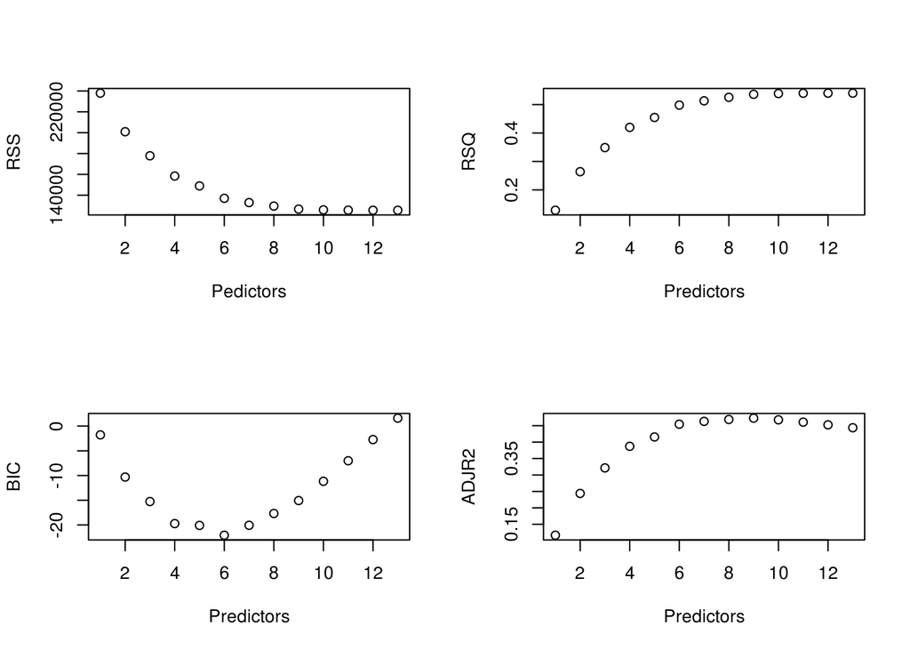

```r
regsum1<-summary(regfit1)
par(mfrow=c(2,2))
plot(regsum1$rss,xlab = "Pedictors",ylab = "RSS")
plot(regsum1$rsq,xlab = "Predictors",ylab = "RSQ")
plot(regsum1$bic,xlab = "Predictors",ylab = "BIC")
plot(regsum1$adjr2,xlab = "Predictors",ylab = "ADJR2")
```

We will use BIC and CP for our statistics. From this graph, the optimal amount of predictors for the BIC is six since it produces the lowest value.

```r
which.min(regsum1$bic)
```

```
## [1] 6
```

```r
which.min(regsum1$cp)
```

```
## [1] 6
```

Both the BIC and CP criterion are lowest when the model has only six predictors.

```r
coef(regfit1,6)
```

```
## (Intercept)        size         lot   statuspen   elemcrest  elemharris
##  119.073017   57.516429   12.809372   10.278640   -7.715081   45.048996
##  elemparker
##  -36.096131
```

These are the top six predictors for regfit1.

```r
model2<-(lm(price~size+lot+statuspen+elemcrest+elemharris+elemparker,data = housing3))
summary(model2)
```

```
##
## Call:
## lm(formula = price ~ size + lot + statuspen + elemcrest + elemharris +
##     elemparker, data = housing3)
##
## Residuals:
##     Min      1Q  Median      3Q     Max
## -97.961 -41.080   0.398  35.073 148.741
##
## Coefficients:
##             Estimate Std. Error t value Pr(>|t|)
## (Intercept)  119.073     59.820   1.991  0.05050 .
## size          57.516     29.688   1.937  0.05679 .
## lot           12.809      4.004   3.199  0.00208 **
## statuspen     10.279     16.780   0.613  0.54219
## elemcrest     -7.715     24.072  -0.320  0.74956
## elemharris    45.049     17.262   2.610  0.01110 *
## elemparker   -36.096     16.520  -2.185  0.03229 *
## ---
## Signif. codes:  0 '***' 0.001 '**' 0.01 '*' 0.05 '.' 0.1 ' ' 1
##
## Residual standard error: 53.81 on 69 degrees of freedom
## Multiple R-squared:  0.2683, Adjusted R-squared:  0.2046
## F-statistic: 4.216 on 6 and 69 DF,  p-value: 0.001136
```

These variables were selected based off of the best 6 variables

## c.

Training and Testing splits

```r
set.seed(1)
train <- sample(76, 38, replace = FALSE)
training<-housing3[train,]
testing<-housing3[-train,]
```

## d.

```r
regfit2<-regsubsets(price~.,data=training,nvmax=14,method="forward")
```

```
## Reordering variables and trying again:
```

```r
regsum2<-summary(regfit2)
summary(regfit2)
```

```
## Subset selection object
## Call: regsubsets.formula(price ~ ., data = training, nvmax = 14, method = "forward")
## 14 Variables  (and intercept)
##                 Forced in Forced out
## size                FALSE      FALSE
## lot                 FALSE      FALSE
## bath                FALSE      FALSE
## bedrooms            FALSE      FALSE
## yearbuilt           FALSE      FALSE
## garagesize          FALSE      FALSE
## statuspen           FALSE      FALSE
## statussld           FALSE      FALSE
## elemcrest           FALSE      FALSE
## elemedge            FALSE      FALSE
## elemedison          FALSE      FALSE
## elemharris          FALSE      FALSE
## elemparker          FALSE      FALSE
## agestandardized     FALSE      FALSE
## 1 subsets of each size up to 13
## Selection Algorithm: forward
##           size lot bath bedrooms yearbuilt agestandardized garagesize statuspen
## 1  ( 1 )  " "  "*" " "  " "      " "       " "             " "        " "
## 2  ( 1 )  " "  "*" " "  " "      " "       " "             " "        " "
## 3  ( 1 )  " "  "*" " "  " "      " "       " "             " "        " "
## 4  ( 1 )  " "  "*" " "  " "      " "       " "             " "        " "
## 5  ( 1 )  "*"  "*" " "  " "      " "       " "             " "        " "
## 6  ( 1 )  "*"  "*" " "  " "      " "       " "             " "        " "
## 7  ( 1 )  "*"  "*" " "  " "      " "       " "             " "        " "
## 8  ( 1 )  "*"  "*" " "  " "      " "       " "             " "        "*"
## 9  ( 1 )  "*"  "*" " "  " "      " "       " "             " "        "*"
## 10  ( 1 ) "*"  "*" " "  "*"      " "       " "             " "        "*"
## 11  ( 1 ) "*"  "*" " "  "*"      "*"       " "             " "        "*"
## 12  ( 1 ) "*"  "*" "*"  "*"      "*"       " "             " "        "*"
## 13  ( 1 ) "*"  "*" "*"  "*"      "*"       " "             "*"        "*"
##           statussld elemcrest elemedge elemedison elemharris elemparker
## 1  ( 1 )  " "       " "       " "      " "        " "        " "
## 2  ( 1 )  " "       " "       " "      " "        " "        "*"
## 3  ( 1 )  " "       " "       "*"      " "        " "        "*"
## 4  ( 1 )  "*"       " "       "*"      " "        " "        "*"
## 5  ( 1 )  "*"       " "       "*"      " "        " "        "*"
## 6  ( 1 )  "*"       " "       "*"      "*"        " "        "*"
## 7  ( 1 )  "*"       " "       "*"      "*"        "*"        "*"
## 8  ( 1 )  "*"       " "       "*"      "*"        "*"        "*"
## 9  ( 1 )  "*"       "*"       "*"      "*"        "*"        "*"
## 10  ( 1 ) "*"       "*"       "*"      "*"        "*"        "*"
## 11  ( 1 ) "*"       "*"       "*"      "*"        "*"        "*"
## 12  ( 1 ) "*"       "*"       "*"      "*"        "*"        "*"
## 13  ( 1 ) "*"       "*"       "*"      "*"        "*"        "*"
```

This is the forward selection process just using the training data.

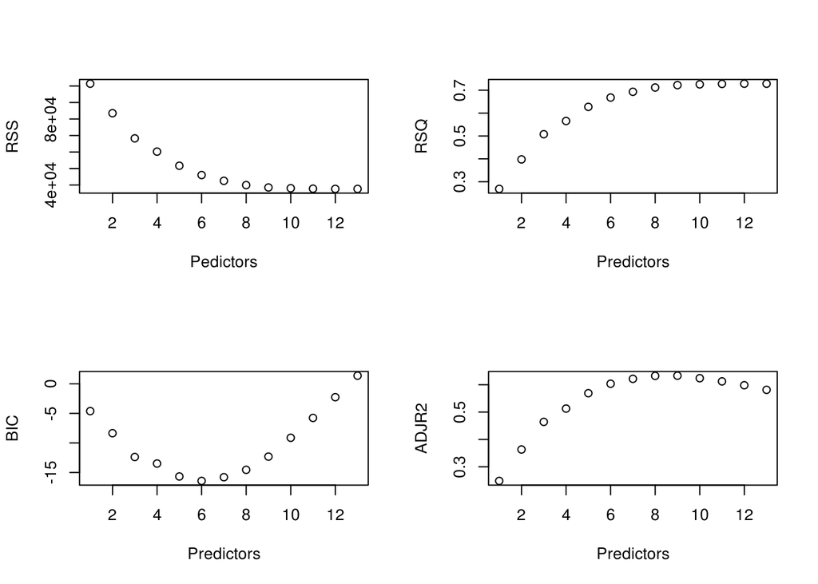

```r
par(mfrow=c(2,2))
plot(regsum2$rss,xlab = "Pedictors",ylab = "RSS")
plot(regsum2$rsq,xlab = "Predictors",ylab = "RSQ")
plot(regsum2$bic,xlab = "Predictors",ylab = "BIC")
plot(regsum2$adjr2,xlab = "Predictors",ylab = "ADJR2")
```

Based on the BIC graph, the optimal amount of predictors is six.

```r
which.min(regsum2$bic)
```

```
## [1] 6
```

```r
which.min(regsum2$cp)
```

```
## [1] 7
```

We will put in six variables even though the cp measurement says seven. This is because the BIC benefits from smaller amounts of predictors.

```r
summary(regsubsets(price~.,data=housing3,nvmax=6,method="forward"))
```

```
## Reordering variables and trying again:
```

```
## Subset selection object
## Call: regsubsets.formula(price ~ ., data = housing3, nvmax = 6, method = "forward")
## 14 Variables  (and intercept)
##                 Forced in Forced out
## size                FALSE      FALSE
## lot                 FALSE      FALSE
## bath                FALSE      FALSE
## bedrooms            FALSE      FALSE
## yearbuilt           FALSE      FALSE
## garagesize          FALSE      FALSE
## statuspen           FALSE      FALSE
## statussld           FALSE      FALSE
## elemcrest           FALSE      FALSE
## elemedge            FALSE      FALSE
## elemedison          FALSE      FALSE
## elemharris          FALSE      FALSE
## elemparker          FALSE      FALSE
## agestandardized     FALSE      FALSE
## 1 subsets of each size up to 7
## Selection Algorithm: forward
##          size lot bath bedrooms yearbuilt agestandardized garagesize statuspen
## 1  ( 1 ) " "  " " " "  " "      " "       " "             "*"        " "
## 2  ( 1 ) " "  " " " "  " "      " "       " "             "*"        " "
## 3  ( 1 ) " "  " " " "  " "      " "       " "             "*"        " "
## 4  ( 1 ) " "  "*" " "  " "      " "       " "             "*"        " "
## 5  ( 1 ) " "  "*" " "  " "      " "       " "             "*"        " "
## 6  ( 1 ) "*"  "*" " "  " "      " "       " "             "*"        " "
## 7  ( 1 ) "*"  "*" " "  "*"      " "       " "             "*"        " "
##          statussld elemcrest elemedge elemedison elemharris elemparker
## 1  ( 1 ) " "       " "       " "      " "        " "        " "
## 2  ( 1 ) " "       " "       " "      "*"        " "        " "
## 3  ( 1 ) " "       " "       " "      "*"        "*"        " "
## 4  ( 1 ) " "       " "       " "      "*"        "*"        " "
## 5  ( 1 ) "*"       " "       " "      "*"        "*"        " "
## 6  ( 1 ) "*"       " "       " "      "*"        "*"        " "
## 7  ( 1 ) "*"       " "       " "      "*"        "*"        " "
```

```r
regfit.best <- regsubsets(price~.,data=training,nvmax=6, really.big = TRUE)
```

```
## Reordering variables and trying again:
```

```r
test.mat <- model.matrix(price~.,data=testing)
```

```r
val.errors <- rep(NA,6)
```

```r
for(i in 1:6){
  coefi=coef(regfit.best,id=i)
  pred=test.mat[,names(coefi)]%*%coefi
  val.errors[i] <- mean((testing$price-pred)^2)}
```

```r
val.errors
```

```
## [1] 4549.240 4611.069 3790.141 3817.808 3923.469 3781.748
```

```r
which.min(val.errors)
```

```
## [1] 6
```

This backs up the fact that the best model should have six variables.

```r
coef(regfit.best,which.min(val.errors))
```

```
##     (Intercept)            size             lot       elemcrest      elemharris
##      162.301971       25.566971       18.021896       12.066297       56.397983
##      elemparker agestandardized
##      -40.184865       -2.018335
```

Here are the six best coeffecients.

```r
model3<-lm(price~size+lot+elemcrest+elemharris+elemparker+agestandardized,data=housing3)
summary(model3)
```

```
##
## Call:
## lm(formula = price ~ size + lot + elemcrest + elemharris + elemparker +
##     agestandardized, data = housing3)
##
## Residuals:
##     Min      1Q  Median      3Q     Max
## -98.860 -39.876   1.893  33.082 147.408
##
## Coefficients:
##                 Estimate Std. Error t value Pr(>|t|)
## (Intercept)      123.740     61.036   2.027  0.04649 *
## size              55.975     30.081   1.861  0.06703 .
## lot               13.100      3.968   3.301  0.00153 **
## elemcrest        -10.195     23.821  -0.428  0.66999
## elemharris        42.740     18.502   2.310  0.02389 *
## elemparker       -37.792     16.611  -2.275  0.02601 *
## agestandardized    1.246      2.891   0.431  0.66790
## ---
## Signif. codes:  0 '***' 0.001 '**' 0.01 '*' 0.05 '.' 0.1 ' ' 1
##
## Residual standard error: 53.88 on 69 degrees of freedom
## Multiple R-squared:  0.2663, Adjusted R-squared:  0.2025
## F-statistic: 4.173 on 6 and 69 DF,  p-value: 0.001231
```

This is the model with the top 6 predictors in it.

## e.

Fourth Candidate Model

```r
library(glmnet)
set.seed(1)
matrix.training<- model.matrix(price ~ ., data = training)
matrix.testing<- model.matrix(price ~ ., data = testing)
grid <-10 ^ seq(10, -2, length = 100)
ridge<-glmnet(matrix.training, training$price, alpha = 0, lambda = grid, thresh = 1e-12)
ridge.cv<-cv.glmnet(matrix.training, training$price, alpha = 0, lambda = grid, thresh = 1e-12)
bestlam<-ridge.cv$lambda.min
bestlam
```

```
## [1] 24.77076
```

```r
ridge.cv$lambda[72]
```

```
## [1] 24.77076
```

The best lambda value is 24.77076.

```r
coef(ridge)[,72]
```

```
##     (Intercept)     (Intercept)            size             lot            bath
##     386.5240598       0.0000000      50.4943374      10.8288142       2.3020203
##        bedrooms       yearbuilt agestandardized      garagesize       statuspen
##     -10.6602571      -0.1098954      -1.0989570       5.4978841      -2.5131937
##       statussld       elemcrest        elemedge      elemedison      elemharris
##     -21.0306476      13.7592444      -5.1698888      41.3375542      37.6489369
##      elemparker
##     -23.5401728
```

These are the top coeffecients for the lowest lambda value or the 72 iteration of the sequence.

## f.

```r
library(pls)
```

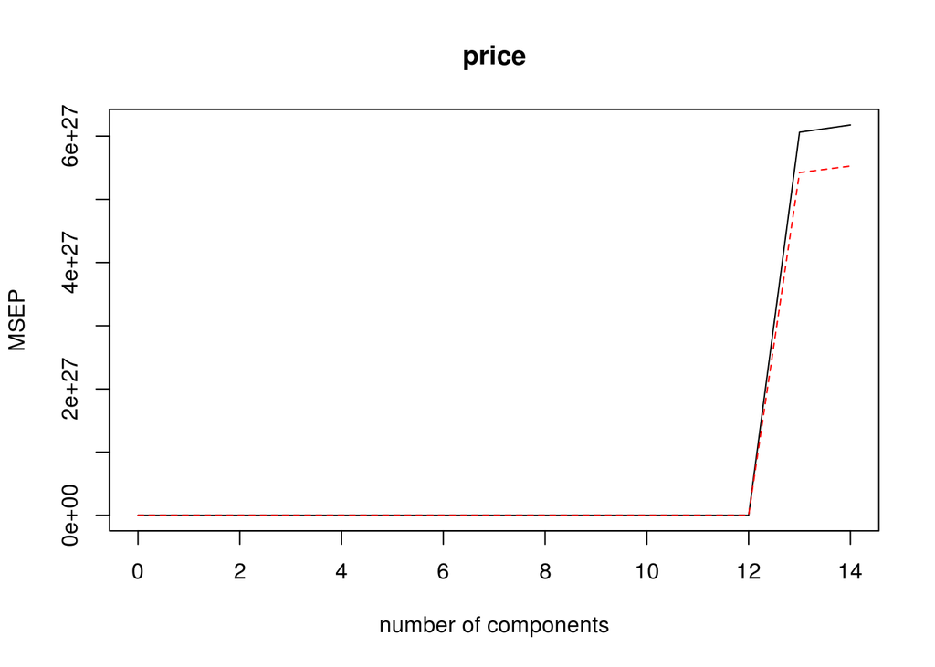

```r
set.seed(1)
model.pls<- plsr(price ~ ., data = training, scale = TRUE, validation = "CV")
validationplot(model.pls, val.type = "MSEP")
```

```r
summary(model.pls)
```

```
## Data:    X dimension: 38 14
##  Y dimension: 38 1
## Fit method: kernelpls
## Number of components considered: 14
##
## VALIDATION: RMSEP
## Cross-validated using 10 random segments.
##        (Intercept)  1 comps  2 comps  3 comps  4 comps  5 comps  6 comps
## CV           62.04    53.17    50.73    51.59    52.50    53.70    53.35
## adjCV        62.04    52.75    49.97    50.62    51.45    52.52    52.21
##        7 comps  8 comps  9 comps  10 comps  11 comps  12 comps   13 comps
## CV       53.20    53.82    55.02     55.28     55.12     55.09  7.786e+13
## adjCV    52.09    52.67    53.80     54.02     53.87     53.84  7.365e+13
##         14 comps
## CV     7.859e+13
## adjCV  7.434e+13
##
## TRAINING: % variance explained
##        1 comps  2 comps  3 comps  4 comps  5 comps  6 comps  7 comps  8 comps
## X        20.29    36.36    46.50    53.81    59.75    68.05    73.39    77.90
## price    48.72    64.67    69.28    71.36    72.27    72.39    72.47    72.58
##        9 comps  10 comps  11 comps  12 comps  13 comps  14 comps
## X        82.91     87.18     89.69     96.34    100.00    101.58
## price    72.73     72.83     72.85     72.85     72.85     72.85
```

```r
model.pls2 <- plsr(price ~ ., data = housing3, scale = TRUE, ncomp = 2)
summary(model.pls2)
```

```
## Data:    X dimension: 76 14
##  Y dimension: 76 1
## Fit method: kernelpls
## Number of components considered: 2
## TRAINING: % variance explained
##        1 comps  2 comps
## X        18.35    33.26
## price    38.26    50.75
```

The summary of model.pls shows that the least amount of cross validation error is with 2 components, so we made a model with ncomp = 2.

## g

```r
#CM1
#This model's prediction outcome had to be squared to account for the square root of the price variable in the model.
mean((price-predict(lg2,housing)^2)[-train]^2)
```

```
## [1] 2627.438
```

```r
#CM2
mean((price-predict(model2,housing))[-train]^2)
```

```
## [1] 3206.247
```

```r
#CM3
mean((price-predict(model3,housing))[-train]^2)
```

```
## [1] 3170.401
```

```r
#CM4
pred.r<-predict(ridge,newx = matrix.testing,s=bestlam)
mean((pred.r-testing$price)^2)
```

```
## [1] 2563.389
```

```r
#CM5
mean((price-predict(model.pls2,housing))[-train]^2)
```

```
## [1] 1932.987
```

Based on the MSE values for each of the five models, it seems that the fifth candidate model is prefferable over the other four in this situation.